# Inmates in Catalonia and Spain

# Inmates in Catalonia and Spain

As a way to introduce myself to R, I followed Paul Bradshaw’s [intro to R](https://github.com/paulbradshaw/Rintro) and [advanced guide](https://github.com/paulbradshaw/Rintro/blob/master/10morethings.md).

I will be adding tips from problems I faced during the development of the tasks.

At the end, some extra exercises I did with the same data can be found.

```r
install.packages("meme")
```

[figure not shown]

```r
library(meme)
u <- "https://i.imgflip.com/uop2m.jpg"
windowsFonts(Impact=windowsFont("TT Impact"))
meme.dog <- meme(u, "Let's do", "data analysis", size = "3")
meme.dog
```

## 1st: Import data

I first generate two objects with the data from a diverse table I downloaded from [Idescat](https://www.idescat.cat/economia/inec?tc=3&id=de03) in Excel format.

Each dataset has 6 columns:

- Year
- Number of convicted inmates
- Percentage of convicted inmates from the total
- Number of preventive inmates
- Percentage of preventive inmates from the total
- Total number of inmates

One datasets includes all Spanish prisions and the other one only the Catalan ones.

I had to adapt the data first as I wanted it to be a CSV.

```r
InmatesCatalonia <- read.csv('ReclusosCatalunya.csv', stringsAsFactors=FALSE)
```

```r
InmatesSpain <- read.csv('ReclusosEspanya.csv', stringsAsFactors=FALSE)
```

I added the second bit of code to prevent numeric columns containing non-numeric values (#NA for data in 2016 in Spain) being treated as ‘factors’, as I want them to be treated as numbers. You can also use “na.strings” inside function.

**Remember!** Replace decimal *commas* with *points* in the Spanish data before creating a CSV. Otherwise, put the argument *dec = “,”*. Also make sure is comma separated and not semicolon, then use *read.csv2()*.

**Remember!** Better if all headers are one word and no symbols. R will replace blank spaces and symbols with points and it might be more difficult to write columns correctly.

**Remember!** Always replace “-”, “N/A” or other “no values” for “NA” so R can treat them as non avaliable data. Otherwise, specify in the argument _na.strings = " “_.

## 2nd: Generate main statistics

I want to get the main statistics from this both datasets.

```r
summary(InmatesCatalonia)
```

```
      Any        NombrePenats  PercentatgePenats NombrePreventius
 Min.   :1994   Min.   :4656   Min.   :76.80     Min.   :1090
 1st Qu.:2000   1st Qu.:5059   1st Qu.:78.90     1st Qu.:1260
 Median :2005   Median :6655   Median :80.20     Median :1415
 Mean   :2005   Mean   :6551   Mean   :80.75     Mean   :1545
 3rd Qu.:2010   3rd Qu.:7852   3rd Qu.:81.70     3rd Qu.:1846
 Max.   :2016   Max.   :8563   Max.   :86.30     Max.   :2259
 PercentatgePreventius     Total
 Min.   :13.70         Min.   : 5915
 1st Qu.:18.30         1st Qu.: 6374
 Median :19.80         Median : 8280
 Mean   :19.25         Mean   : 8100
 3rd Qu.:21.10         3rd Qu.: 9580
 Max.   :23.20         Max.   :10525
```

```r
summary(InmatesSpain)
```

```
      Any        NombrePenats   PercentatgePenats NombrePreventius
 Min.   :1994   Min.   :32501   Min.   :74.20     Min.   : 7684
 1st Qu.:2000   1st Qu.:36111   1st Qu.:76.12     1st Qu.: 9731
 Median :2005   Median :46799   Median :78.35     Median :11604
 Mean   :2005   Mean   :46049   Mean   :79.05     Mean   :11830
 3rd Qu.:2010   3rd Qu.:55269   3rd Qu.:79.72     3rd Qu.:13568
 Max.   :2016   Max.   :60499   Max.   :87.50     Max.   :17849
                NA's   :1       NA's   :1         NA's   :1
 PercentatgePreventius     Total
 Min.   :12.50         Min.   :42756
 1st Qu.:19.07         1st Qu.:45791
 Median :21.60         Median :60215
 Mean   :20.66         Mean   :58058
 3rd Qu.:23.88         3rd Qu.:67016
 Max.   :25.80         Max.   :76079
 NA's   :1             NA's   :1
```

## 3rd: Join two datasets

I want to join both datasets in one. It may not be really good as both have the same column and row labels for the same years. Their data is just from different territories.

Instead of merging, I added the different rows for same labels.

```r
InmatesCatEspRows <- rbind(InmatesCatalonia, InmatesSpain)
```

```r
summary(InmatesCatEspRows)
```

```
      Any        NombrePenats   PercentatgePenats NombrePreventius
 Min.   :1994   Min.   : 4656   Min.   :74.20     Min.   : 1090
 1st Qu.:1999   1st Qu.: 6655   1st Qu.:77.50     1st Qu.: 1415
 Median :2005   Median : 8563   Median :79.50     Median : 2259
 Mean   :2005   Mean   :25861   Mean   :79.92     Mean   : 6573
 3rd Qu.:2011   3rd Qu.:46263   3rd Qu.:81.40     3rd Qu.:11439
 Max.   :2016   Max.   :60499   Max.   :87.50     Max.   :17849
                NA's   :1       NA's   :1         NA's   :1
 PercentatgePreventius     Total
 Min.   :12.50         Min.   : 5915
 1st Qu.:18.30         1st Qu.: 8280
 Median :20.50         Median :10525
 Mean   :19.94         Mean   :32524
 3rd Qu.:22.50         3rd Qu.:59375
 Max.   :25.80         Max.   :76079
 NA's   :1             NA's   :1
```

The data in the object generated just doesn’t make sense because it can’t be comapared. But the function worked.

```r
InmatesCatEspColumns <- cbind(InmatesCatalonia, InmatesSpain)
```

```r
summary(InmatesCatEspColumns)
```

```
      Any        NombrePenats  PercentatgePenats NombrePreventius
 Min.   :1994   Min.   :4656   Min.   :76.80     Min.   :1090
 1st Qu.:2000   1st Qu.:5059   1st Qu.:78.90     1st Qu.:1260
 Median :2005   Median :6655   Median :80.20     Median :1415
 Mean   :2005   Mean   :6551   Mean   :80.75     Mean   :1545
 3rd Qu.:2010   3rd Qu.:7852   3rd Qu.:81.70     3rd Qu.:1846
 Max.   :2016   Max.   :8563   Max.   :86.30     Max.   :2259

 PercentatgePreventius     Total            Any        NombrePenats
 Min.   :13.70         Min.   : 5915   Min.   :1994   Min.   :32501
 1st Qu.:18.30         1st Qu.: 6374   1st Qu.:2000   1st Qu.:36111
 Median :19.80         Median : 8280   Median :2005   Median :46799
 Mean   :19.25         Mean   : 8100   Mean   :2005   Mean   :46049
 3rd Qu.:21.10         3rd Qu.: 9580   3rd Qu.:2010   3rd Qu.:55269
 Max.   :23.20         Max.   :10525   Max.   :2016   Max.   :60499
                                                      NA's   :1
 PercentatgePenats NombrePreventius PercentatgePreventius
 Min.   :74.20     Min.   : 7684    Min.   :12.50
 1st Qu.:76.12     1st Qu.: 9731    1st Qu.:19.07
 Median :78.35     Median :11604    Median :21.60
 Mean   :79.05     Mean   :11830    Mean   :20.66
 3rd Qu.:79.72     3rd Qu.:13568    3rd Qu.:23.88
 Max.   :87.50     Max.   :17849    Max.   :25.80
 NA's   :1         NA's   :1        NA's   :1
     Total
 Min.   :42756
 1st Qu.:45791
 Median :60215
 Mean   :58058
 3rd Qu.:67016
 Max.   :76079
 NA's   :1
```

## 4th: Another way of importing data

In this case I use the function “read.table”, where I have to put more details ( *arguments* ).

```r
InmatesSpainTable <- read.table(file = "ReclusosEspanya.csv", sep = ",", stringsAsFactors = F, header = T)
```

```r
summary(InmatesSpainTable)
```

```
      Any        NombrePenats   PercentatgePenats NombrePreventius
 Min.   :1994   Min.   :32501   Min.   :74.20     Min.   : 7684
 1st Qu.:2000   1st Qu.:36111   1st Qu.:76.12     1st Qu.: 9731
 Median :2005   Median :46799   Median :78.35     Median :11604
 Mean   :2005   Mean   :46049   Mean   :79.05     Mean   :11830
 3rd Qu.:2010   3rd Qu.:55269   3rd Qu.:79.72     3rd Qu.:13568
 Max.   :2016   Max.   :60499   Max.   :87.50     Max.   :17849
                NA's   :1       NA's   :1         NA's   :1
 PercentatgePreventius     Total
 Min.   :12.50         Min.   :42756
 1st Qu.:19.07         1st Qu.:45791
 Median :21.60         Median :60215
 Mean   :20.66         Mean   :58058
 3rd Qu.:23.88         3rd Qu.:67016
 Max.   :25.80         Max.   :76079
 NA's   :1             NA's   :1
```

## 5th: Creating subsets of data

I will create a different vector (variable) for the columns “Nombre Penats” and “Nombre Preventius” for both datasets. With it I will be able to calculate later the evolution of the proportion of inmates in Catalonia in relation to the number in Spain.

```r
ConvictedCatalonia <- InmatesCatalonia$NombrePenats
ConvictedSpain <- InmatesSpain$NombrePenats
PreventiveCatalonia <- InmatesCatalonia$NombrePreventius
PreventiveSpain <- InmatesSpain$NombrePreventius
```

I can also use the *“subset”* function if I didn’t want to use the complete column (eg. only a specific period of time).

```r
InmatesCatalonia0616 <- subset(InmatesCatalonia, InmatesCatalonia$Any > 2005)
```

### Reorder the data

I also create a dataset of the Inmates in Catalan prison reversing the order. With the years in chronological order I will be able to plot charts more visually.

```r
ConvictedCataloniaYear <- data.frame(InmatesCatalonia$Any[23:1], ConvictedCatalonia[23:1])
```

I do the same for the Spanish data.

```r
ConvictedSpainYear <- data.frame(InmatesSpain$Any[23:1], ConvictedSpain[23:1])
```

I repeat it with the Preventive Inmates data from both regions.

```r
PreventiveCataloniaYear <- data.frame(InmatesCatalonia$Any[23:1], PreventiveCatalonia[23:1])
PreventiveSpainYear <- data.frame(InmatesSpain$Any[23:1], PreventiveSpain[23:1])
```

## 6th: Queries and filters

Same and different statistics from the summary function can be asked individually.

For example, standard deviation.

```r
sd(ConvictedCatalonia)
```

```
[1] 1453.174
```

```r
sd(ConvictedSpain)
```

```
[1] NA
```

```r
sd(PreventiveCatalonia)
```

```
[1] 367.1338
```

```r
sd(PreventiveSpain)
```

```
[1] NA
```

### Maximum

Which is the maximum of convicted inmates in Catalan prisons in a year?

```r
max(AllInmatesColumns$ConvictedCatalonia.23.1.)
```

```
[1] 8563
```

Which are the row names (year) for the maximum data in every column? I use a function.

```r
rownames(AllInmatesColumns

         [apply(

           AllInmatesColumns,

           #This refers I want the maximum per each column.
           2,

           which.max), ])
```

```
[1] "2010"   "2009"   "2008"   "2008.1"
```

## 7th: Create a chart

Elements in my barplot code:

- I use the convicted number column of the “ConvictedCataloniaYear” dataframe, as I reordered the data in chronological order there.
- I also added “names.arg” with the years column in that dataframe to make them appear in the x axis.
- Last, I put “main” with the title I want to use between inverted commas.

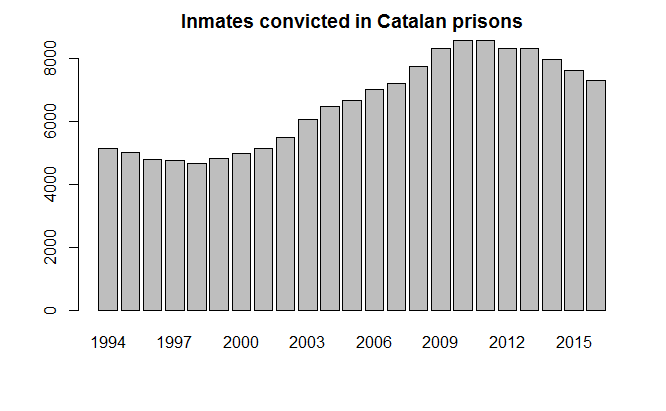

```r
barplot(height = ConvictedCataloniaYear$ConvictedCatalonia.23.1., names.arg = ConvictedCataloniaYear$InmatesCatalonia.Any.23.1., main = 'Inmates convicted in Catalan prisons')
```

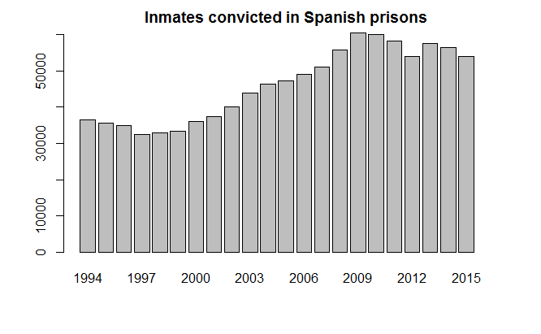

```r
barplot(height = ConvictedSpainYear$ConvictedSpain.23.1., names.arg = ConvictedSpainYear$InmatesSpain.Any.23.1., main = 'Inmates convicted in Spanish prisons')
```

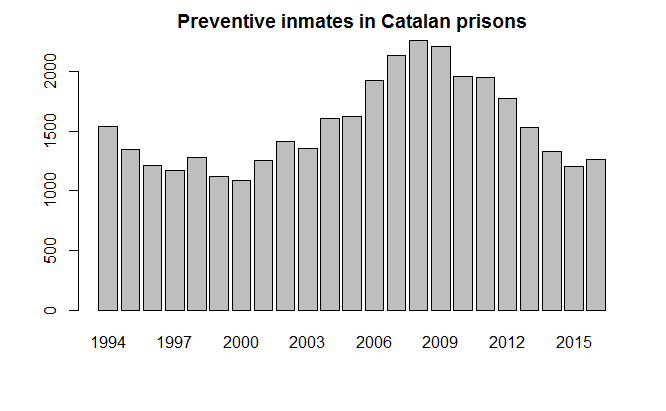

```r
barplot(height = PreventiveCataloniaYear$PreventiveCatalonia.23.1., names.arg = PreventiveCataloniaYear$InmatesCatalonia.Any.23.1., main = 'Preventive inmates in Catalan prisons')
```

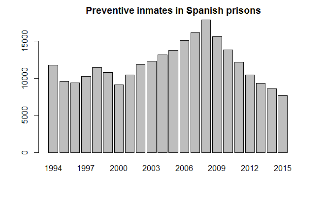

```r
barplot(height = PreventiveSpainYear$PreventiveSpain.23.1., names.arg = PreventiveSpainYear$InmatesSpain.Any.23.1., main = 'Preventive inmates in Spanish prisons')
```

## 8th: Export as CSV

Create CSV files for the new tables binded in R. And another for the summary statistics generated.

```r
write.csv(InmatesCatEspColumns, file='InmatesCatEspColumns.csv')
```

```r
write.csv(summary(InmatesCatEspColumns), file='SummaryInmatesCatEspColumns.csv')
```

## 9th: Installing packages

I will install the [dplyr package](http://dplyr.tidyverse.org/), a grammar of data manipulation.

```r
install.packages("dplyr")
```

## 10th: Using package

I will use the function that creates a new dataset with all the rows from two datasets.

```r
library("dplyr")
AllInmates <- bind_rows(InmatesCatalonia,InmatesSpain)
```

I get the same table as when using the internal function `InmatesCatEspRows <- rbind(InmatesCatalonia, InmatesSpain)`

## 11th: Import data from Excel

I have to install a package that has this function. In this case, the “readxl”

```r
install.packages("readxl")
```

Then, in the function to import it I also specify that I want it to avoid importing the first 6 rows as they include titles and information that is not part of the table.

```r
library(readxl)
SpanishPopulation <- read_excel('Poblacion españa.xlsx', skip=6)
```

## 12th Choosing specific columns

The table with Spanish population has data from each year 2 times, I just want the data recorded on January each year. I will create a new dataset specifying these columns.

```r
SpanishPopulationJanuary <- SpanishPopulation[ c(1, 2, 4, 6, 8, 10, 12, 14, 16, 18, 20, 22, 24, 26, 28, 30, 32)]
```

# EXTRA!

I’ll create a dataset with the data of convicted and preventive inmates in Catalonia and Spain.

I will do it in 3 different ways:

1. Binding columns (“values” generated before). I also include [23:1] after values to indicate I want them in chronological order (reverse from the original data columns) and I add the year column from another dataset to act as names column:

```r
AllInmatesColumns <- data.frame (ConvictedCatalonia[23:1], ConvictedSpain[23:1], PreventiveCatalonia[23:1], PreventiveSpain[23:1], row.names = InmatesCatEspColumns$Any[23:1])
```

2. Selecting specific columns with the same data from the binded dataset *“InmatesCatEspColumns”*.

```r
AllInmatesColumnsOut <- InmatesCatEspColumns[c(1, 2, 4, 8, 10)]
```

```r
AllInmatesSubset <- subset(AllInmatesColumns, select = c("ConvictedCatalonia.23.1.","PreventiveCatalonia.23.1.", "ConvictedSpain.23.1.", "ConvictedSpain.23.1."))
```

I prefer the first one, as I can control the column names (I named them before when creating the values), include a vector as “row names” and reorder the column values.

## Multiple bars chart

I want to plot this multiple columns dataset.

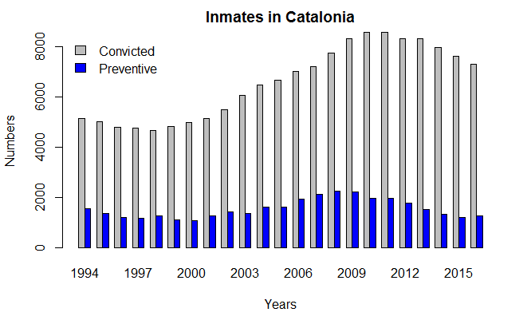

```r
#Create a dataset specifying the columns you want on the bar chart. In this case, from the dataset with reversed columns 'AllInmatesColumns', I want the colums ConvictedCatalonia.23.1.[1] and PreventiveCatalonia.23.1[3].
AllInmatesColumnsCatalonia <- AllInmatesColumns[c(1,3)]
#I need to transpose the rows and columns, as the barplot function will juxtapose each column together on the chart.I use function `t()`.
AllInmatesColumnsCataloniaT <- t(AllInmatesColumnsCatalonia)
#I select the colours I want each column to be.
colours <- c("grey", "blue")
#I plot the chart as a "matrix" and not "hight" because I want more than one column to be ploted.
barplot(as.matrix(AllInmatesColumnsCataloniaT),

        #With this code I say I want each cell in a row to be ploted in bars side by side (juxtaposed) and not one above the other (stacked).
        beside=TRUE,

        #This is for the title.
        main="Inmates in Catalonia",

        #This for the axis labels
        ylab = "Numbers", xlab = "Years",

        #This to use the colours written before for each bar.
        col=colours
        )
#I want to add a legend
legend(

  #Where to place it
  "topleft",

  #Labels for the legend
  c("Convicted","Preventive"),

  #I want it without borders
  bty="n",

  #Which filling to use? The colours writen before
  fill=colours)
```

## Lines chart

```r
plot_colors <- c("blue", "red", "forest green", "yellow")
plot(AllInmatesColumns$ConvictedCatalonia.23.1.,

     #I want a line uniting the data
     type="l",

     #I want it to use the first colour writen.
     col=plot_colors[1],

     xlab="Years", ylab="Number",

     #Thickness of the line
     lwd=2,

     #I don't want axes because I will draw them after with specific labels
     axes=F,

     #I need a very long range Y axis to display all the data. The default argument gets just enough Y values as to see the first column plotted on the graph
     ylim=c(0,60000)
     )
axis(
  #I am modifying the below axis
  1,

  #I want to take out the default labels
  lab=F)
```

```r
axis(
  #I am modifying the x axis below
  1,

  #I want ticks on the 23 years of my dataset
  at=1:23,

  #Labels for this axis
  lab=row.names(AllInmatesColumns),

  #I want smaller labels
  cex.axis=0.6)
axis(
  #I am modifying the y axis on the left
  2,

  #I want the default labels
  lab=T,

  cex.axis=0.6)
```

```r
#Create a box arround the chart
box()
#Plot the line for convicted inmates in Catalan prisons with thicker red dashed line
lines(AllInmatesColumns$PreventiveCatalonia.23.1., type="l", lty=2, lwd=2,
  col=plot_colors[2])
```

```r
#Plot the line for convicted inmates in Catalan prisons with thicker green dotted line
lines(AllInmatesColumns$ConvictedSpain.23.1., type="l", lty=3, lwd=2,
  col=plot_colors[3])
#Plot the line for convicted inmates in Catalan prisons with thicker yellow dotted line
lines(AllInmatesColumns$PreventiveSpain.23.1., type="l", lty=3, lwd=2,
  col=plot_colors[4])
```

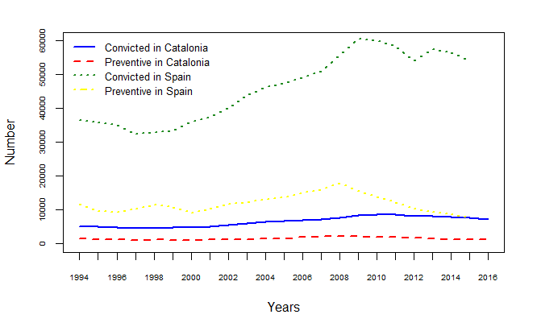

```r
# Create a legend
legend("topleft",

  #Labels for the legend
  c("Convicted in Catalonia", "Preventive in Catalonia", "Convicted in Spain", "Preventive in Spain"), cex=0.8, col=plot_colors,
   lty=1:4, lwd=2, bty="n")
```

This is not really useful because data from “convicted in Spanish prisons” is so huge in contrast with the others. But is to prove that it can be done.

## Percentage of preventive inmates from total

To calculate the percentage of one column in relation to another I will create a function. Then, I can use it with all the column combinations I want.

```r
Percentage <- function(x, y) {
        percentage <- (x / (x + y)) *100

  return(percentage)
}
```

Now I call the function to find out the percentage of preventive inmates in Catalonia from the total inmates, per year. It will create a new vector.

```r
PercentagePreventiveCatalonia <- Percentage(PreventiveCatalonia, ConvictedCatalonia)
#Without 2016 data, easier to visualise.
PercentagePreventiveCatalonia <- subset(PercentagePreventiveCatalonia, PercentagePreventiveCatalonia < 2016)
```

To do it with the data from Spanish prisions, I have to create a subset of data that doesent include 2016, as there is NA data for this year.

Subset of Spanish prisons without year 2016 (NA data)

```r
InmatesSpain9415 <- subset(InmatesSpain, InmatesSpain$Any < 2016)
```

Now I can call the function. Whith the first code I store it in a new vector.with the second I just call to view it.

```r
PercentagePreventiveSpain <- Percentage(InmatesSpain9415$NombrePreventius, InmatesSpain9415$NombrePenats)
Percentage(InmatesSpain9415$NombrePreventius, InmatesSpain9415$NombrePenats)
```

```
 [1] 12.47119 13.21962 13.91747 16.21811 17.23805 18.71661 20.47871
 [8] 24.26521 24.04918 23.53134 22.47191 22.08337 21.88391 22.76319
[15] 21.76657 20.17559 24.42247 25.78093 23.98494 21.18162 21.14253
[22] 24.41443
```

I can use it as many times as I want, just replacing x and y for the names of the vectors or columns I want. And even for years.

Which % did preventive inmates in Catalonia represented from the total preventive inmates in Spain in 2009?

```r
Percentage(InmatesCatalonia[8,4], InmatesSpain[8,4])
```

```
[1] 12.42271
```

All the years.

```r
Percentage(InmatesCatalonia[4], InmatesSpain[4])
```

| NombrePreventius |
| --- |
| NA |
| 13.565804 |
| 13.374320 |
| 14.129933 |
| 14.485752 |
| 13.837861 |
| 12.390781 |
| 12.422709 |
| 11.234335 |
| 11.679711 |

[output cut: 13 more lines]

```r
PreventiveCataloniaPercentage <- Percentage(InmatesCatalonia[4], InmatesSpain[4])
PreventiveCataloniaPercentage <- subset(PreventiveCataloniaPercentage, PreventiveCataloniaPercentage < 2016)
class(PreventiveCataloniaPercentage)
```

```
[1] "data.frame"
```

```r
as.numeric(as.character(PreventiveCataloniaPercentage))
```

```
NAs introduced by coercion
```

```
[1] NA
```

```r
class(PreventiveCataloniaPercentage$NombrePreventius)
```

```
[1] "numeric"
```

Visualize it.

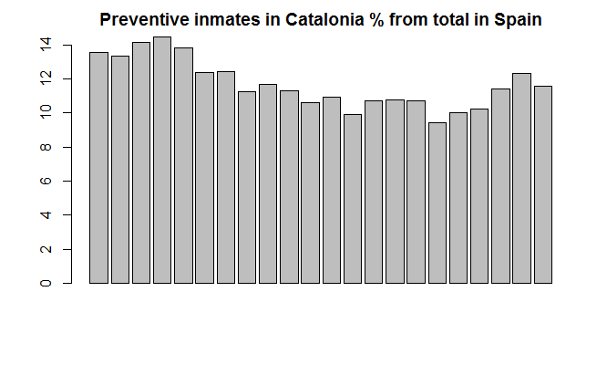

```r
barplot(height = PreventiveCataloniaPercentage$NombrePreventius, main = 'Preventive inmates in Catalonia % from total in Spain')
```

The same but for convicted inmates

```r
ConvictedCataloniaPercentage <- Percentage(InmatesCatalonia[2], InmatesSpain[2])
ConvictedCataloniaPercentage <- subset(ConvictedCataloniaPercentage, ConvictedCataloniaPercentage < 2016)
```

Visualize it.

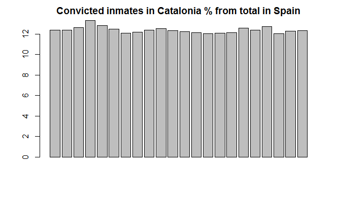

```r
barplot(height = ConvictedCataloniaPercentage$NombrePenats, main = 'Convicted inmates in Catalonia % from total in Spain')
```

## Lines chart: evolution of preventive inmates from total in Catalonia and Spain

```r
plot(PercentagePreventiveCatalonia[22:1], type="l", col=plot_colors[1], xlab="Years", ylab="Number", lwd=2, axes=F, ylim=c(10,30), main="Percentage of preventive inmates")
axis(1, lab=F)
```

```r
axis(1, at=1:22, cex.axis=0.6, lab=InmatesSpain9415$Any[22:1])
axis(2, lab=T, cex.axis=0.6)
```

```r
box()
lines(PercentagePreventiveSpain[22:1], type="l", lty=2, lwd=2, col=plot_colors[2])
```

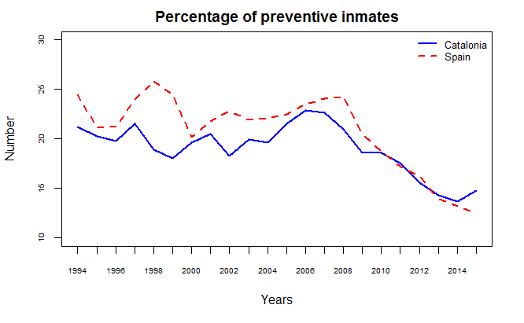

```r
legend("topright", c("Catalonia", "Spain"), cex=0.8, col=plot_colors,
   lty=1:4, lwd=2, bty="n")
```